# 2-D Tight Binding - Graphene

[figure not shown]

**Graphene** is a compound composed of a single layer of carbon atoms arranged in a hexagonal lattice. It posesses some interesting properties that make it a possible candidate for the next generation of semiconductors. Solid state physicists use a quantum mechanical approximation called the **Tight Binding Model** to calculate these properties. The model assumes that electrons are generally tightly bound to their atoms, but they may hop to different atoms at a certain energy cost. This simple model leads to complex behavior.

## Graphene Unit Cell and Brillouin Zone

We'll start by taking a look at the geometry of the problem. Just for fun, we'll generate the relevant images in Matplotlib:

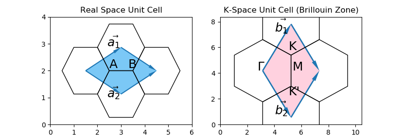

```python
%matplotlib notebook
import numpy as np
import pandas as pd
import matplotlib.pyplot as plt
import matplotlib.patches as mpatches

def draw_vector(axis, x, y, dx, dy, width):
    axis.add_patch(mpatches.Arrow(x, y, dx, dy, width))

def draw_hexagon(axis, x, y, radius, orientation=np.pi/6):
    axis.add_patch(mpatches.RegularPolygon((x,y), 6, radius=radius, orientation=orientation, fill=False))

# Physical constants for real space
a = 1
x = 1.5
y = 2

ax = 3*a/2
ay = np.sqrt(3)*a/2

# Initialize multi-plot figure
fig, [ax1, ax2] = plt.subplots(1, 2, figsize=(14,5))
ax1.set_title("Real Space Unit Cell")
ax1.set_xbound(0, 6*a)
ax1.set_ybound(0, 4*a)

ax1.text(x+0.9, y+0.9, r'$\vec{a_1}$', fontsize=18)
ax1.text(x+0.9, y-1, r'$\vec{a_2}$', fontsize=18)
ax1.text(x+1, y+0.1, 'A', fontsize=18)
ax1.text(x+1.8, y+0.1, 'B', fontsize=18)

unit_cell = np.array([[x, y], [x+ax, y+ay], [x+2*ax, y], [x+ax, y-ay]])
ax1.add_patch(mpatches.Polygon(unit_cell, color='xkcd:lightblue'))
width = 0.2
draw_vector(ax1, x, y, ax, ay, width)
draw_vector(ax1, x, y, ax, -ay, width)
draw_vector(ax1, x+ax, y+ay, ax, -ay, width)
draw_vector(ax1, x+ax, y-ay, ax, ay, width)

draw_hexagon(ax1, x, y, a)
draw_hexagon(ax1, x+ax, y+ay, a)
draw_hexagon(ax1, x+2*ax, y, a)
draw_hexagon(ax1, x+ax, y-ay, a)

# Physical constants for inverse space
b = 2*np.pi/(3*a)
bx = b
by = b * np.sqrt(3)

# Initialize second plot
ax2.set_title("K-Space Unit Cell (Brillouin Zone)")
ax2.set_xbound(0, 5*b)
ax2.set_ybound(0, 4*b)

x = 1.5*b
y = 2*b
width = 0.5

# Draw Brillouin Zone Unit Cell
bz_cell = np.array([[x, y], [x+bx, y+by], [x+2*bx, y], [x+bx, y-by]])
ax2.add_patch(mpatches.Polygon(bz_cell, color='xkcd:light pink'))
draw_vector(ax2, x, y, bx, by, width)
draw_vector(ax2, x, y, bx, -by, width)
draw_vector(ax2, x+bx, y+by, bx, -by, width)
draw_vector(ax2, x+bx, y-by, bx, by, width)

# Draw hexagonal momentum-space unit cells
draw_hexagon(ax2, x, y, 2*b/np.sqrt(3), 0)
draw_hexagon(ax2, x+2*bx, y, 2*b/np.sqrt(3),0)
draw_hexagon(ax2, x+bx, y+by, 2*b/np.sqrt(3),0)
draw_hexagon(ax2, x+bx, y-by, 2*b/np.sqrt(3),0)

ax2.text(x+0.9, y+3, r'$\vec{b_1}$', fontsize=18)
ax2.text(x+0.9, y-3.4, r'$\vec{b_2}$', fontsize=18)
ax2.text(x-0.4, y, r'$\Gamma$', fontsize=18)
ax2.text(x+2.2, y, 'M', fontsize=18)
ax2.text(x+1.9, y+1.6, 'K', fontsize=18)
ax2.text(x+1.9, y-1.9, 'K\'', fontsize=18)

plt.show();
```

Graphene's "hexagonal" lattice can properly be thought of as a diamond-shaped unit cell containing two atoms A and B. If $a$ represents the distance between carbon atoms, then the unit cell can be defined by two basis vectors, $\vec{a_1}=\frac{a}{2}(3,\sqrt{3})$ and $\vec{a_2}=\frac{a}{2}(3,-\sqrt{3})$.

To examine the electron energy spectrum, it's much more useful to look at this problem in momentum space. This involves a Fourier Transform from the original position vectors $\vec{a_1}$ and $\vec{a_2}$ to the momentum vectors $\vec{b_1}$ and $\vec{b_2}$. The unit cell in momentum space is known as a Brillouin Zone. The points $\Gamma$, K, and M represent points of reference that we use to display band structure.

## Tight Binding Model

Since Graphene's unit cell has two atoms, the simplest possible tight binding model is represented by the hamiltonian

\begin{equation} H = -t\sum_i (A^\dagger_i B_i + B^\dagger_i A_i). + V_0\sum_i(A^\dagger_i A_i + B^\dagger B), \end{equation}

where $A$ and $B$ represent each atomic site, $t$ is the hopping energy, and $V_0$ is the binding energy. We can think of the hamiltonian as a matrix:

\begin{equation} H = \sum_i \begin{pmatrix} A_i^* \\ B_i^* \end{pmatrix} \begin{pmatrix} V_0 & -t \\ -t & V_0 \end{pmatrix} \begin{pmatrix} A_i & B_i \end{pmatrix}, \end{equation}

where $\mathcal{H}=\begin{pmatrix} V_0 & -t \\ -t & V_0 \end{pmatrix}$ is the *kernel* of the hamiltonian.

To compute what we're after (the electron energy spectrum), we'll want to convert this problem to momentum space. A Fourier Transform adds a factor of $e^{i \overrightarrow{k}\cdot\overrightarrow{r}}$ to each interaction, where $\vec{r}$ is the distance between the two particles in real space. The geometry of the problem gives us the three nearest-neighbor vectors,

\begin{align} \delta_1 &= \frac{a}{2}(1, \sqrt{3}) \\ \delta_2 &= \frac{a}{2}(1, -\sqrt{3}) \\ \delta_3 &= a(-1, 0). \end{align}

The hamiltonian matrix in momentum space is then

\begin{equation} \mathcal{H}(k) =\begin{pmatrix} V_0 & -t(e^{i \overrightarrow{k} \cdot \overrightarrow{\delta_1}} + e^{i \overrightarrow{k} \cdot \overrightarrow{\delta_2}} + e^{i \overrightarrow{k} \cdot \overrightarrow{\delta_3}}) \\ -t(e^{-i \overrightarrow{k} \cdot \overrightarrow{\delta_1}} + e^{-i \overrightarrow{k} \cdot \overrightarrow{\delta_2}} + e^{-i \overrightarrow{k} \cdot \overrightarrow{\delta_3}}) & V_0\end{pmatrix} \end{equation}

.

From here, computing the eigenvalues of the matrix will give us the energy spectrum we are looking for. This is a simple matter in NumPy:

```python
v_0 = 0
t = 1
a = 1

d_1 = a * np.array((-1, 0))
d_2 = a/2 * np.array((1, np.sqrt(3)))
d_3 = a/2 * np.array((1, -np.sqrt(3)))

def hop(k, r):
    return -t * np.exp(1j * np.dot(k, r))

def hop_conj(k, r):
    return -t * np.exp(-1j * np.dot(k, r))

def energy(k):
    h = np.matrix([[v_0,  hop(k, d_1) + hop(k, d_2) + hop(k, d_3)],
                   [hop_conj(k, d_1) + hop_conj(k, d_2) + hop_conj(k, d_3), v_0]])
    return np.real(np.linalg.eigvals(h))
```

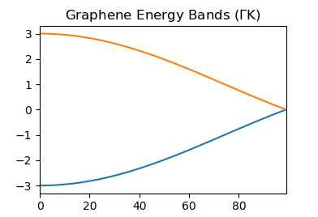

```python
k = [(kx, kx/np.sqrt(3)) for kx in np.linspace(0, b, 100)]
bands = pd.DataFrame(list(map(energy, k))).apply(np.sort, axis=1)
bands.plot(title=r'Graphene Energy Bands ($\Gamma$K)', legend=());
```

As expected from the two atoms in each unit cell, there are two electron energy bands. This plot shows why K was chosen as a significant point: the energy bands meet here in a cone, allowing electrons to flow from one band to another with no energy cost.

2-d plots feel a bit limiting, don't they? Instead of calculating k-values in a line, we can compute the energy bands for the entire Brillouin Zone and use Matplotlib's 3d functions to get a better picture of the system.

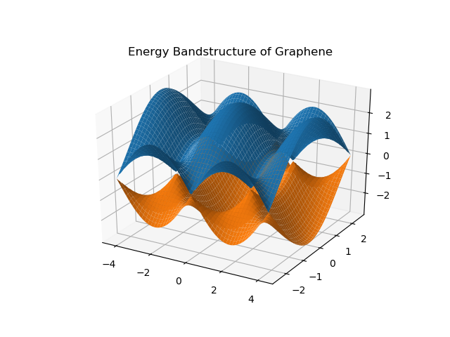

```python
from mpl_toolkits.mplot3d import Axes3D
fig = plt.figure()
axis = fig.add_subplot(111, projection='3d')
axis.set_title("Energy Bandstructure of Graphene")

kx = np.linspace(-2*b, 2*b, 100)
ky = np.linspace(-2*b/np.sqrt(3), 2*b/np.sqrt(3), 100)
X, Y = np.meshgrid(kx, ky)

Z = np.array(list(map(energy, zip(X.flatten(), Y.flatten()))))
axis.plot_surface(X, Y, Z[:,0].reshape((100,100)))
axis.plot_surface(X, Y, Z[:,1].reshape((100,100)));
```

With a 3-d plot, the hexagonal structure of the energy bands is visible, as are the cones at the K-points.